# Stockholm Wind Analysis for Sailing

William Bergekrans

2021-11

# Introduction

This short study aims to explore how many days of the year are fit for sailing.

## The data

The data used for this project is retrieved from SMHI. The data is measured at five different locations and includes over 1.5 million observations.

The locations are: * Landsort + Data from 1995 - 2021. * Berga + Data from 1952 - 2021. * Svenska Högarna + Data from 1949 - 2021. + Observations once every hour between 2010 - 2021. * Skarpö + Data from 1976 - 2021. * Söderarm + Data from 1941 - 2021.

In order to have comparable data only data from the period 1996 to 2021 is used. I believe this to be a sufficient sample size in order to spot both local trends over the year (if there are any) as well as more long term trends.

Furthermore, another positive effect of this choice of data is that there are more precise measurements from these years compared to earlier. The precision of the measurements is marked in the data as either approved or suspect values. To better align the data with each other 8 observations from each day is used, one observation from every three hours.

## General Wind speed analysis

Intuitively wind speed should follow a normal distribution. The following plot show the distribution of different wind speeds at Landsort during 2020.

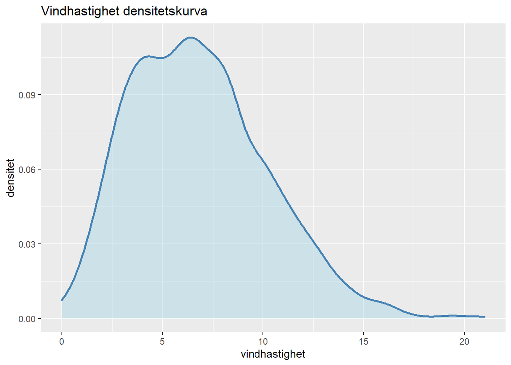

Winds are likely to fall in the range between 3-8 m/s. These are winds that I would consider to be good conditions for sailing, especially in the region over 5 m/s. The distribution have some bell-shaped characteristics but it is slightly skewed towards higher wind strengths.

In order to grasp if there are any differences over the year I calculate the two-sided moving average over the 30 closest observations, which is a couple of days.

The following graph show the moving average winds over the years 2017-2020 at landsort.

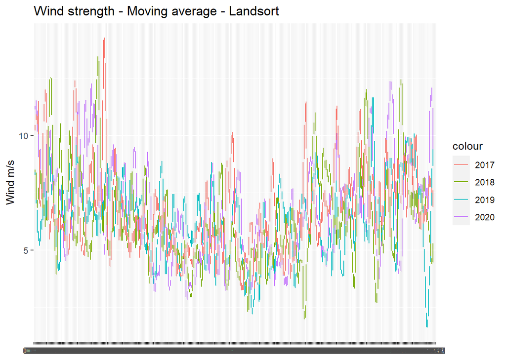

During 2020 there is a clear trend of higher wind speeds during the winter months.